# svm

## DataCo SMART SUPPLY CHAIN FOR BIG DATA ANALYSIS

A DataSet of Supply Chains used by the company DataCo Global was used for the analysis. Dataset of Supply Chain , which allows the use of Machine Learning Algorithms and R Software.

Areas of important registered activities : Provisioning , Production , Sales , Commercial Distribution.It also allows the correlation of Structured Data with Unstructured Data for knowledge generation.

**Type Data :** \ Structured Data : DataCoSupplyChainDataset.csv \ Unstructured Data : tokenized_access_logs.csv (Clickstream)

**Types of Products :** Clothing , Sports , and Electronic Supplies

Additionally it is attached in another file called DescriptionDataCoSupplyChain.csv, the description of each of the variables of the DataCoSupplyChainDatasetc.csv.

### Goal

The goal of this analysis is to predict whether the package delivery gonna be late or not (variable Late_delivery_risk)

```python
import pandas as pd
import matplotlib.pyplot as plt
import numpy as np
from scipy import stats
import seaborn as sns

from imblearn.over_sampling import SMOTE
from sklearn.model_selection import train_test_split
from sklearn import svm
from sklearn.metrics import accuracy_score, f1_score, recall_score, precision_score
from sklearn.model_selection import GridSearchCV
import lime
from lime import lime_tabular

import logging
import os
import warnings
from urllib.parse import urlparse
import mlflow
import mlflow.sklearn
from mlflow.models import infer_signature

pd.set_option('display.max_columns', 100)
pd.set_option('display.max_colwidth', None)
logging.basicConfig(level=logging.WARN)
logger = logging.getLogger(__name__)
```

```python
data_raw = pd.read_csv("D:/Kuliah/semester_3/kecerdasan_buatan/Github/Artificial_Inteligence/Pertemuan_4/DataCoSupplyChainDataset.csv", encoding="ISO-8859-1")
data_unstructured = pd.read_csv("D:/Kuliah/semester_3/kecerdasan_buatan/Github/Artificial_Inteligence/Pertemuan_4/tokenized_access_logs.csv", encoding="ISO-8859-1")
data_desc = pd.read_csv("D:/Kuliah/semester_3/kecerdasan_buatan/Github/Artificial_Inteligence/Pertemuan_4/DescriptionDataCoSupplyChain.csv", encoding="ISO-8859-1")
```

```python
# Column Description
data_desc
```

|  | FIELDS | DESCRIPTION |
| --- | --- | --- |
| 0 | Type | : Type of transaction made |
| 1 | Days for shipping (real) | : Actual shipping days of the purchased product |
| 2 | Days for shipment (scheduled) | : Days of scheduled delivery of the purchased product |
| 3 | Benefit per order | : Earnings per order placed |
| 4 | Sales per customer | : Total sales per customer made per customer |
| 5 | Delivery Status | : Delivery status of orders: Advance shipping , Late delivery , Shipping canceled , Shipping on time |
| 6 | Late_delivery_risk | : Categorical variable that indicates if sending is late (1), it is not late (0). |
| 7 | Category Id | : Product category code |
| 8 | Category Name | : Description of the product category |
| 9 | Customer City | : City where the customer made the purchase |
| 10 | Customer Country | : Country where the customer made the purchase |
| 11 | Customer Email | : Customer's email |
| 12 | Customer Fname | : Customer name |
| 13 | Customer Id | : Customer ID |
| 14 | Customer Lname | : Customer lastname |
| 15 | Customer Password | : Masked customer key |
| 16 | Customer Segment | : Types of Customers: Consumer , Corporate , Home Office |
| 17 | Customer State | : State to which the store where the purchase is registered belongs |
| 18 | Customer Street | : Street to which the store where the purchase is registered belongs |
| 19 | Customer Zipcode | : Customer Zipcode |
| 20 | Department Id | : Department code of store |
| 21 | Department Name | : Department name of store |
| 22 | Latitude | : Latitude corresponding to location of store |
| 23 | Longitude | : Longitude corresponding to location of store |
| 24 | Market | : Market to where the order is delivered : Africa , Europe , LATAM , Pacific Asia , USCA |
| 25 | Order City | : Destination city of the order |
| 26 | Order Country | : Destination country of the order |
| 27 | Order Customer Id | : Customer order code |
| 28 | order date (DateOrders) | : Date on which the order is made |
| 29 | Order Id | : Order code |
| 30 | Order Item Cardprod Id | : Product code generated through the RFID reader |
| 31 | Order Item Discount | : Order item discount value |
| 32 | Order Item Discount Rate | : Order item discount percentage |
| 33 | Order Item Id | : Order item code |
| 34 | Order Item Product Price | : Price of products without discount |
| 35 | Order Item Profit Ratio | : Order Item Profit Ratio |
| 36 | Order Item Quantity | : Number of products per order |
| 37 | Sales | : Value in sales |
| 38 | Order Item Total | : Total amount per order |
| 39 | Order Profit Per Order | : Order Profit Per Order |
| 40 | Order Region | : Region of the world where the order is delivered : Southeast Asia ,South Asia ,Oceania ,Eastern Asia, West Asia , West of USA , US Center , West Africa, Central Africa ,North Africa ,Western Europe … |
| 41 | Order State | : State of the region where the order is delivered |
| 42 | Order Status | : Order Status : COMPLETE , PENDING , CLOSED , PENDING_PAYMENT ,CANCELED , PROCESSING ,SUSPECTED_FRAUD ,ON_HOLD ,PAYMENT_REVIEW |
| 43 | Product Card Id | : Product code |
| 44 | Product Category Id | : Product category code |
| 45 | Product Description | : Product Description |
| 46 | Product Image | : Link of visit and purchase of the product |
| 47 | Product Name | : Product Name |
| 48 | Product Price | : Product Price |
| 49 | Product Status | : Status of the product stock :If it is 1 not available , 0 the product is available |
| 50 | Shipping date (DateOrders) | : Exact date and time of shipment |
| 51 | Shipping Mode | : The following shipping modes are presented : Standard Class , First Class , Second Class , Same Day |

```python
data_raw.head()
```

|  | Type | Days for shipping (real) | Days for shipment (scheduled) | Benefit per order | Sales per customer | Delivery Status | Late_delivery_risk | Category Id | Category Name | Customer City | Customer Country | Customer Email | Customer Fname | Customer Id | Customer Lname | Customer Password | Customer Segment | Customer State | Customer Street | Customer Zipcode | Department Id | Department Name | Latitude | Longitude | Market | Order City | Order Country | Order Customer Id | order date (DateOrders) | … |
| --- | --- | --- | --- | --- | --- | --- | --- | --- | --- | --- | --- | --- | --- | --- | --- | --- | --- | --- | --- | --- | --- | --- | --- | --- | --- | --- | --- | --- | --- | --- |
| 0 | DEBIT | 3 | 4 | 91.250000 | 314.640015 | Advance shipping | 0 | 73 | Sporting Goods | Caguas | Puerto Rico | XXXXXXXXX | Cally | 20755 | Holloway | XXXXXXXXX | Consumer | PR | 5365 Noble Nectar Island | 725.0 | 2 | Fitness | 18.251453 | -66.037056 | Pacific Asia | Bekasi | Indonesia | 20755 | 1/31/2018 22:56 | … |
| 1 | TRANSFER | 5 | 4 | -249.089996 | 311.359985 | Late delivery | 1 | 73 | Sporting Goods | Caguas | Puerto Rico | XXXXXXXXX | Irene | 19492 | Luna | XXXXXXXXX | Consumer | PR | 2679 Rustic Loop | 725.0 | 2 | Fitness | 18.279451 | -66.037064 | Pacific Asia | Bikaner | India | 19492 | 1/13/2018 12:27 | … |
| 2 | CASH | 4 | 4 | -247.779999 | 309.720001 | Shipping on time | 0 | 73 | Sporting Goods | San Jose | EE. UU. | XXXXXXXXX | Gillian | 19491 | Maldonado | XXXXXXXXX | Consumer | CA | 8510 Round Bear Gate | 95125.0 | 2 | Fitness | 37.292233 | -121.881279 | Pacific Asia | Bikaner | India | 19491 | 1/13/2018 12:06 | … |
| 3 | DEBIT | 3 | 4 | 22.860001 | 304.809998 | Advance shipping | 0 | 73 | Sporting Goods | Los Angeles | EE. UU. | XXXXXXXXX | Tana | 19490 | Tate | XXXXXXXXX | Home Office | CA | 3200 Amber Bend | 90027.0 | 2 | Fitness | 34.125946 | -118.291016 | Pacific Asia | Townsville | Australia | 19490 | 1/13/2018 11:45 | … |
| 4 | PAYMENT | 2 | 4 | 134.210007 | 298.250000 | Advance shipping | 0 | 73 | Sporting Goods | Caguas | Puerto Rico | XXXXXXXXX | Orli | 19489 | Hendricks | XXXXXXXXX | Corporate | PR | 8671 Iron Anchor Corners | 725.0 | 2 | Fitness | 18.253769 | -66.037048 | Pacific Asia | Townsville | Australia | 19489 | 1/13/2018 11:24 | … |

```python
data_unstructured.head()
```

|  | Product | Category | Date | Month | Hour | Department | ip | url |
| --- | --- | --- | --- | --- | --- | --- | --- | --- |
| 0 | adidas Brazuca 2017 Official Match Ball | baseball & softball | 9/1/2017 6:00 | Sep | 6 | fitness | 37.97.182.65 | /department/fitness/category/baseball%20&%20softball/product/adidas%20Brazuca%202017%20Official%20Match%20Ball |
| 1 | The North Face Women's Recon Backpack | hunting & shooting | 9/1/2017 6:00 | Sep | 6 | fan shop | 206.56.112.1 | /department/fan%20shop/category/hunting%20&%20shooting/product/The%20North%20Face%20Women's%20Recon%20Backpack |
| 2 | adidas Kids' RG III Mid Football Cleat | featured shops | 9/1/2017 6:00 | Sep | 6 | apparel | 215.143.180.0 | /department/apparel/category/featured%20shops/product/adidas%20Kids'%20RG%20III%20Mid%20Football%20Cleat |
| 3 | Under Armour Men's Compression EV SL Slide | electronics | 9/1/2017 6:00 | Sep | 6 | footwear | 206.56.112.1 | /department/footwear/category/electronics/product/Under%20Armour%20Men's%20Compression%20EV%20SL%20Slide |
| 4 | Pelican Sunstream 100 Kayak | water sports | 9/1/2017 6:01 | Sep | 6 | fan shop | 136.108.56.242 | /department/fan%20shop/category/water%20sports/product/Pelican%20Sunstream%20100%20Kayak |

```python
data_raw.isnull().sum()
```

```
Type                                  0
Days for shipping (real)              0
Days for shipment (scheduled)         0
Benefit per order                     0
Sales per customer                    0
Delivery Status                       0
Late_delivery_risk                    0
Category Id                           0
Category Name                         0
Customer City                         0
Customer Country                      0
Customer Email                        0
Customer Fname                        0
Customer Id                           0
Customer Lname                        8
Customer Password                     0
Customer Segment                      0
Customer State                        0
Customer Street                       0
Customer Zipcode                      3
Department Id                         0
Department Name                       0
Latitude                              0
Longitude                             0
Market                                0
Order City                            0
Order Country                         0
Order Customer Id                     0
order date (DateOrders)               0
Order Id                              0
Order Item Cardprod Id                0
Order Item Discount                   0
Order Item Discount Rate              0
Order Item Id                         0
Order Item Product Price              0
Order Item Profit Ratio               0
Order Item Quantity                   0
Sales                                 0
Order Item Total                      0
Order Profit Per Order                0
Order Region                          0
Order State                           0
Order Status                          0
Order Zipcode                    155679
Product Card Id                       0
Product Category Id                   0
Product Description              180519
Product Image                         0
Product Name                          0
Product Price                         0
Product Status                        0
shipping date (DateOrders)            0
Shipping Mode                         0
dtype: int64
```

```python
data_raw.head()
```

|  | Type | Days for shipping (real) | Days for shipment (scheduled) | Benefit per order | Sales per customer | Delivery Status | Late_delivery_risk | Category Id | Category Name | Customer City | Customer Country | Customer Email | Customer Fname | Customer Id | Customer Lname | Customer Password | Customer Segment | Customer State | Customer Street | Customer Zipcode | Department Id | Department Name | Latitude | Longitude | Market | Order City | Order Country | Order Customer Id | order date (DateOrders) | … |
| --- | --- | --- | --- | --- | --- | --- | --- | --- | --- | --- | --- | --- | --- | --- | --- | --- | --- | --- | --- | --- | --- | --- | --- | --- | --- | --- | --- | --- | --- | --- |
| 0 | DEBIT | 3 | 4 | 91.250000 | 314.640015 | Advance shipping | 0 | 73 | Sporting Goods | Caguas | Puerto Rico | XXXXXXXXX | Cally | 20755 | Holloway | XXXXXXXXX | Consumer | PR | 5365 Noble Nectar Island | 725.0 | 2 | Fitness | 18.251453 | -66.037056 | Pacific Asia | Bekasi | Indonesia | 20755 | 1/31/2018 22:56 | … |
| 1 | TRANSFER | 5 | 4 | -249.089996 | 311.359985 | Late delivery | 1 | 73 | Sporting Goods | Caguas | Puerto Rico | XXXXXXXXX | Irene | 19492 | Luna | XXXXXXXXX | Consumer | PR | 2679 Rustic Loop | 725.0 | 2 | Fitness | 18.279451 | -66.037064 | Pacific Asia | Bikaner | India | 19492 | 1/13/2018 12:27 | … |
| 2 | CASH | 4 | 4 | -247.779999 | 309.720001 | Shipping on time | 0 | 73 | Sporting Goods | San Jose | EE. UU. | XXXXXXXXX | Gillian | 19491 | Maldonado | XXXXXXXXX | Consumer | CA | 8510 Round Bear Gate | 95125.0 | 2 | Fitness | 37.292233 | -121.881279 | Pacific Asia | Bikaner | India | 19491 | 1/13/2018 12:06 | … |
| 3 | DEBIT | 3 | 4 | 22.860001 | 304.809998 | Advance shipping | 0 | 73 | Sporting Goods | Los Angeles | EE. UU. | XXXXXXXXX | Tana | 19490 | Tate | XXXXXXXXX | Home Office | CA | 3200 Amber Bend | 90027.0 | 2 | Fitness | 34.125946 | -118.291016 | Pacific Asia | Townsville | Australia | 19490 | 1/13/2018 11:45 | … |
| 4 | PAYMENT | 2 | 4 | 134.210007 | 298.250000 | Advance shipping | 0 | 73 | Sporting Goods | Caguas | Puerto Rico | XXXXXXXXX | Orli | 19489 | Hendricks | XXXXXXXXX | Corporate | PR | 8671 Iron Anchor Corners | 725.0 | 2 | Fitness | 18.253769 | -66.037048 | Pacific Asia | Townsville | Australia | 19489 | 1/13/2018 11:24 | … |

```python
data_raw.dtypes
```

```
Type                              object
Days for shipping (real)           int64
Days for shipment (scheduled)      int64
Benefit per order                float64
Sales per customer               float64
Delivery Status                   object
Late_delivery_risk                 int64
Category Id                        int64
Category Name                     object
Customer City                     object
Customer Country                  object
Customer Email                    object
Customer Fname                    object
Customer Id                        int64
Customer Lname                    object
Customer Password                 object
Customer Segment                  object
Customer State                    object
Customer Street                   object
Customer Zipcode                 float64
Department Id                      int64
Department Name                   object
Latitude                         float64
Longitude                        float64
Market                            object
Order City                        object
Order Country                     object
Order Customer Id                  int64
order date (DateOrders)           object
Order Id                           int64
Order Item Cardprod Id             int64
Order Item Discount              float64
Order Item Discount Rate         float64
Order Item Id                      int64
Order Item Product Price         float64
Order Item Profit Ratio          float64
Order Item Quantity                int64
Sales                            float64
Order Item Total                 float64
Order Profit Per Order           float64
Order Region                      object
Order State                       object
Order Status                      object
Order Zipcode                    float64
Product Card Id                    int64
Product Category Id                int64
Product Description              float64
Product Image                     object
Product Name                      object
Product Price                    float64
Product Status                     int64
shipping date (DateOrders)        object
Shipping Mode                     object
dtype: object
```

```python
col_to_object = ["Customer Id", "Customer Zipcode", "Department Id", "Order Customer Id", "Order Id", "Order Item Cardprod Id",
                 "Order Item Id", "Product Card Id", "Product Category Id", "Product Status", "Late_delivery_risk", "Category Id",
                 "Latitude", "Longitude", "Order Zipcode", "Product Description"]
col_to_date =  ["order date (DateOrders)", "shipping date (DateOrders)"]

data_1 = data_raw
data_1[col_to_object] = data_1[col_to_object].astype(str)
data_1[col_to_date] = data_1[col_to_date].apply(pd.to_datetime, format='%m/%d/%Y %H:%M')
```

### Descriptive Statistics

```python
print(data_1.describe(include='all'))
```

```
          Type  Days for shipping (real)  Days for shipment (scheduled)  \
count   180519             180519.000000                  180519.000000
unique       4                       NaN                            NaN
top      DEBIT                       NaN                            NaN
freq     69295                       NaN                            NaN
first      NaN                       NaN                            NaN
last       NaN                       NaN                            NaN
mean       NaN                  3.497654                       2.931847
std        NaN                  1.623722                       1.374449
min        NaN                  0.000000                       0.000000
25%        NaN                  2.000000                       2.000000
50%        NaN                  3.000000                       4.000000
75%        NaN                  5.000000                       4.000000
max        NaN                  6.000000                       4.000000

        Benefit per order  Sales per customer Delivery Status  \
count       180519.000000       180519.000000          180519
unique                NaN                 NaN               4
top                   NaN                 NaN   Late delivery
freq                  NaN                 NaN           98977
first                 NaN                 NaN             NaN
last                  NaN                 NaN             NaN
mean            21.974989          183.107609             NaN
std            104.433526          120.043670             NaN
min          -4274.979980            7.490000             NaN
25%              7.000000          104.379997             NaN
50%             31.520000          163.990005             NaN
75%             64.800003          247.399994             NaN
max            911.799988         1939.989990             NaN

       Late_delivery_risk Category Id Category Name Customer City  \
count              180519      180519        180519        180519
unique                  2          51            50           563
top                     1          17        Cleats        Caguas
freq                98977       24551         24551         66770
first                 NaN         NaN           NaN           NaN
last                  NaN         NaN           NaN           NaN
mean                  NaN         NaN           NaN           NaN
std                   NaN         NaN           NaN           NaN
min                   NaN         NaN           NaN           NaN
```

[output cut: 184 more lines]

```

       shipping date (DateOrders)   Shipping Mode
count                      180519          180519
unique                      63701               4
top           2016-01-05 05:58:00  Standard Class
freq                           10          107752
first         2015-01-03 00:00:00             NaN
last          2018-02-06 22:14:00             NaN
mean                          NaN             NaN
std                           NaN             NaN
min                           NaN             NaN
25%                           NaN             NaN
50%                           NaN             NaN
75%                           NaN             NaN
max                           NaN             NaN
```

Since SVM is relatively demanding algorithm in case of using this large dataset, lets do stratified sampling based on Late_delivery_risk

```python
data_1 = data_1.groupby('Late_delivery_risk', group_keys=False).apply(lambda x: x.sample(frac=0.1))
```

### Bar Chart

```python
data_cat = data_1.select_dtypes(include=['object'])
data_cat.head()
```

|  | Type | Delivery Status | Late_delivery_risk | Category Id | Category Name | Customer City | Customer Country | Customer Email | Customer Fname | Customer Id | Customer Lname | Customer Password | Customer Segment | Customer State | Customer Street | Customer Zipcode | Department Id | Department Name | Latitude | Longitude | Market | Order City | Order Country | Order Customer Id | Order Id | Order Item Cardprod Id | Order Item Id | Order Region | Order State | … |
| --- | --- | --- | --- | --- | --- | --- | --- | --- | --- | --- | --- | --- | --- | --- | --- | --- | --- | --- | --- | --- | --- | --- | --- | --- | --- | --- | --- | --- | --- | --- |
| 131982 | CASH | Advance shipping | 0 | 46 | Indoor/Outdoor Games | Opelousas | EE. UU. | XXXXXXXXX | Mary | 38 | Smith | XXXXXXXXX | Consumer | LA | 2805 Crystal Moor | 70570.0 | 7 | Fan Shop | 30.24161911 | -97.89144135 | Pacific Asia | Yakarta | Indonesia | 38 | 27562 | 1014 | 68994 | Southeast Asia | Yakarta | … |
| 122089 | TRANSFER | Shipping canceled | 0 | 29 | Shop By Sport | Caguas | Puerto Rico | XXXXXXXXX | Nicholas | 12002 | Davis | XXXXXXXXX | Corporate | PR | 3977 Old Dale Point | 725.0 | 5 | Golf | 18.28413773 | -66.37057495 | LATAM | Villa Nueva | Guatemala | 12002 | 9109 | 627 | 22722 | Central America | Guatemala | … |
| 59741 | DEBIT | Advance shipping | 0 | 43 | Camping & Hiking | Wheeling | EE. UU. | XXXXXXXXX | Mary | 3477 | Smith | XXXXXXXXX | Corporate | WV | 1397 Colonial Point | 26003.0 | 7 | Fan Shop | 40.0639801 | -80.72141266 | Europe | Villefontaine | Francia | 3477 | 12481 | 957 | 31224 | Western Europe | Auvernia-Ródano-Alpes | … |
| 146707 | DEBIT | Shipping on time | 0 | 45 | Fishing | Caguas | Puerto Rico | XXXXXXXXX | Kyle | 10253 | Smith | XXXXXXXXX | Consumer | PR | 1023 Honey Grove | 725.0 | 7 | Fan Shop | 18.21958351 | -66.3706131 | Africa | Quelimane | Mozambique | 10253 | 46243 | 1004 | 115597 | East Africa | Zambezia | … |
| 79280 | DEBIT | Shipping on time | 0 | 48 | Water Sports | Cerritos | EE. UU. | XXXXXXXXX | Teresa | 10142 | Smith | XXXXXXXXX | Consumer | CA | 3504 Dusty View Loop | 90703.0 | 7 | Fan Shop | 33.80993271 | -118.0119705 | USCA | Springfield | Estados Unidos | 10142 | 34938 | 1073 | 87289 | East of USA | Ohio | … |

```python
data_cat.nunique()
```

```
Type                          4
Delivery Status               4
Late_delivery_risk            2
Category Id                  51
Category Name                50
Customer City               558
Customer Country              2
Customer Email                1
Customer Fname              597
Customer Id                9564
Customer Lname             1036
Customer Password             1
Customer Segment              3
Customer State               44
Customer Street            5851
Customer Zipcode            988
Department Id                11
Department Name              11
Latitude                   6556
Longitude                  3360
Market                        5
Order City                 2769
Order Country               146
Order Customer Id          9564
Order Id                  15872
Order Item Cardprod Id      118
Order Item Id             18052
Order Region                 23
Order State                 912
Order Status                  9
Order Zipcode               453
Product Card Id             118
Product Category Id          51
Product Description           1
Product Image               118
Product Name                118
Product Status                1
Shipping Mode                 4
dtype: int64
```

```python
retained_cat_col = ["Type", "Delivery Status", "Shipping Mode", "Late_delivery_risk"]
data_cat = data_cat[retained_cat_col]
data_cat.head()
```

|  | Type | Delivery Status | Shipping Mode | Late_delivery_risk |
| --- | --- | --- | --- | --- |
| 131982 | CASH | Advance shipping | Standard Class | 0 |
| 122089 | TRANSFER | Shipping canceled | First Class | 0 |
| 59741 | DEBIT | Advance shipping | Standard Class | 0 |
| 146707 | DEBIT | Shipping on time | Standard Class | 0 |
| 79280 | DEBIT | Shipping on time | Standard Class | 0 |

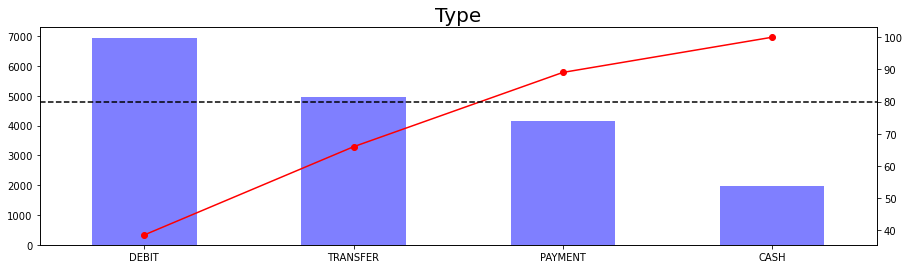

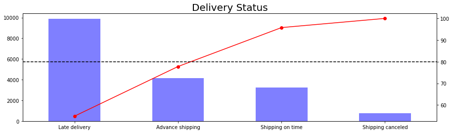

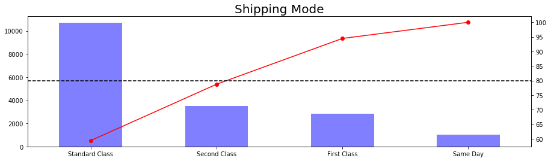

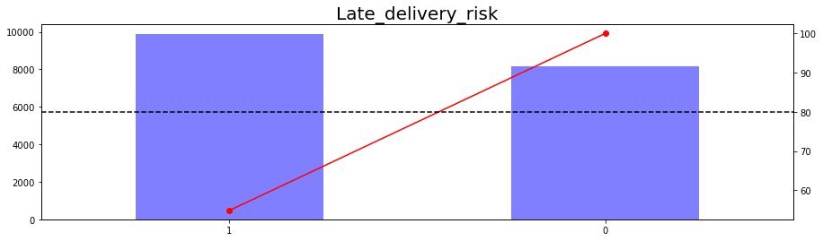

```python
for column in data_cat:
    plt.figure(figsize=(15,4))

    # Calculate value counts and sort by descending order
    value_counts = data_cat[column].value_counts().sort_values(ascending=False)

    # Create bar chart
    value_counts.plot(kind='bar', color='blue', alpha=0.5)

    # Calculate cumulative sums and convert to percentage of total
    cumulative_sums = value_counts.cumsum() / value_counts.sum() * 100

    # Create Pareto line
    cumulative_sums.plot(kind='line', marker='o', color='red', secondary_y=True)

    # Add dotted line at 80%
    plt.axhline(y=80, color='k', linestyle='--')

    plt.title(column, fontdict={'fontsize': 20})
    plt.show()
```

From the visualization

a. about 80% type of transaction made consist of DEBIT, TRANSFER, and PAYMENT \ b. about 80% delivery status consist of Late Delivery, Advance Shipping, and Shipping on Time \ c. about 80% shipping mode used were Standard Class and Second Class \ d. Late delivery risk, which is the label we want to predict were almost equal in occurence

TODO-> bisa eksplorasi gimana statistiknya kalau Late delivery risk nya 0 dan 1

# Box Plot

```python
data_num = data_1.select_dtypes(exclude=['object', 'datetime64[ns]'])
data_num.head()
```

|  | Days for shipping (real) | Days for shipment (scheduled) | Benefit per order | Sales per customer | Order Item Discount | Order Item Discount Rate | Order Item Product Price | Order Item Profit Ratio | Order Item Quantity | Sales | Order Item Total | Order Profit Per Order | Product Price |
| --- | --- | --- | --- | --- | --- | --- | --- | --- | --- | --- | --- | --- | --- |
| 131982 | 3 | 4 | -47.139999 | 173.929993 | 25.99 | 0.13 | 49.980000 | -0.27 | 4 | 199.919998 | 173.929993 | -47.139999 | 49.980000 |
| 122089 | 2 | 1 | 77.470001 | 188.949997 | 11.00 | 0.06 | 39.990002 | 0.41 | 5 | 199.949997 | 188.949997 | 77.470001 | 39.990002 |
| 59741 | 2 | 4 | 119.839996 | 254.979996 | 45.00 | 0.15 | 299.980011 | 0.47 | 1 | 299.980011 | 254.979996 | 119.839996 | 299.980011 |
| 146707 | 4 | 4 | 151.309998 | 387.980011 | 12.00 | 0.03 | 399.980011 | 0.39 | 1 | 399.980011 | 387.980011 | 151.309998 | 399.980011 |
| 79280 | 4 | 4 | 46.400002 | 159.990005 | 40.00 | 0.20 | 199.990005 | 0.29 | 1 | 199.990005 | 159.990005 | 46.400002 | 199.990005 |

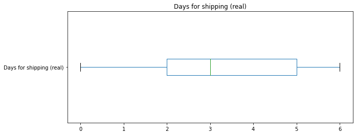

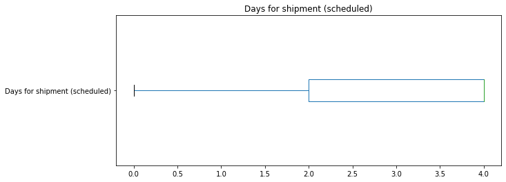

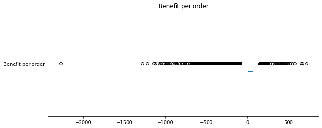

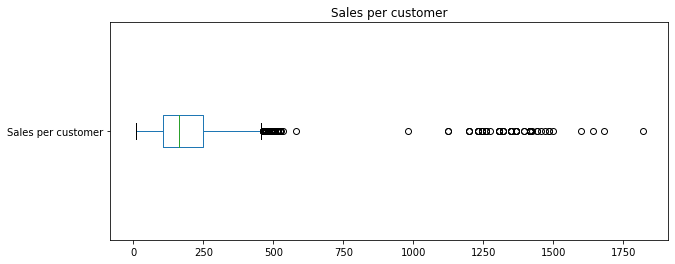

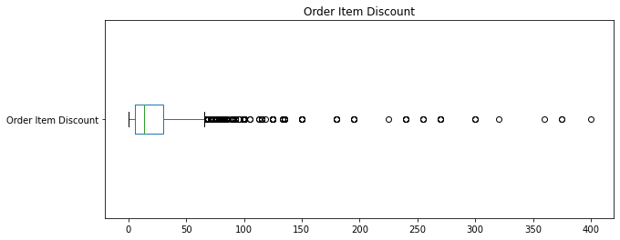

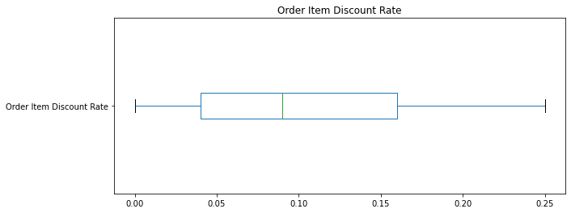

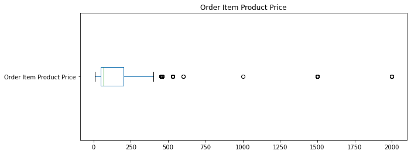

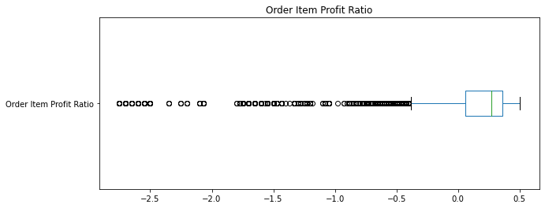

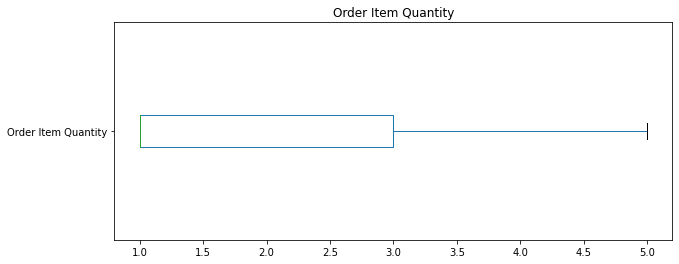

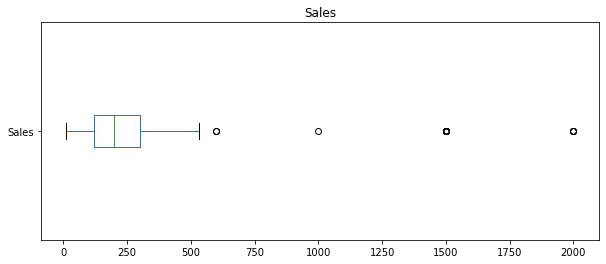

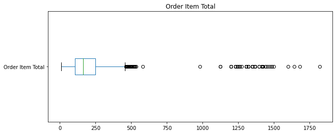

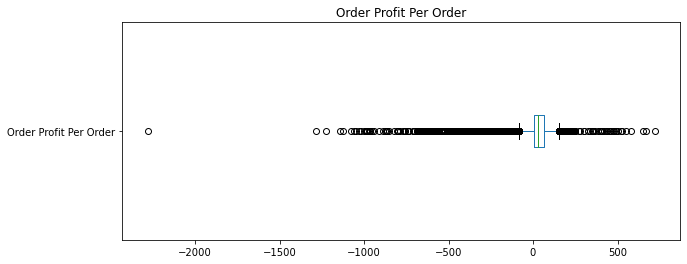

[1 more figures not shown]

```python
for column in data_num:
    plt.figure(figsize=(10,4))
    data_num.boxplot([column], vert=False, grid=False)
    plt.title(column)
    plt.show()
```

From boxplot created above, several point can be derived:

a. Outliers exist in Benefit per order, Sales per customer, Order Item Discount, Order Item Product Price, Order Item Profit Ratio, Sales, Order Item Total, Order Profit Per Order, Product Price

### Data Preprocessing

According to prior search, SVM most likely does not have prior assumptions, therefore we can proceed with current data and make preparation for training, test, and validation data. The special treatment is we gonna use stratified sampling accross data.

Source: https://stackoverflow.com/questions/35422072/major-assumptions-of-machine-learning-classifiers-lg-svm-and-decision-trees

```python
rand_seed = 123
np.random.seed(rand_seed)
```

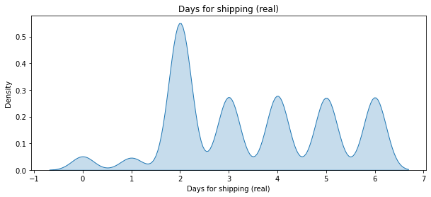

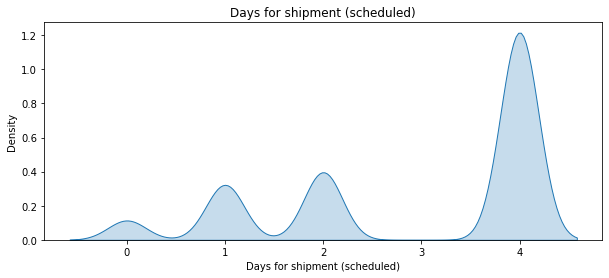

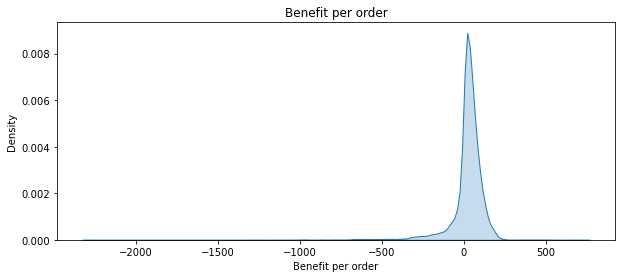

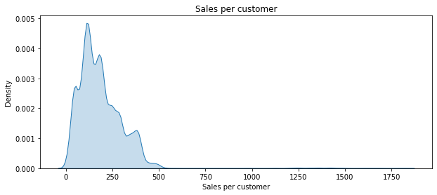

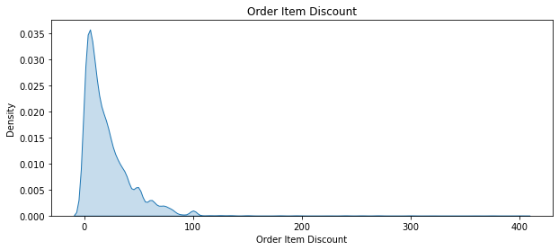

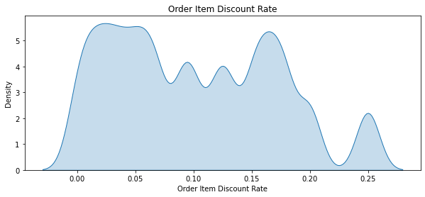

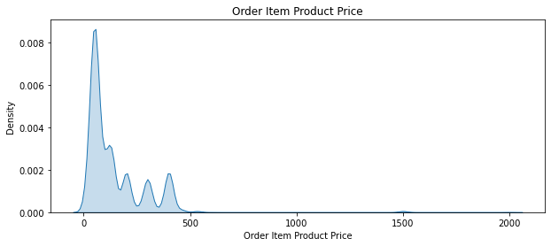

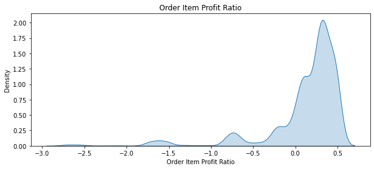

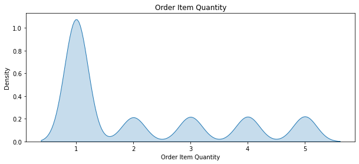

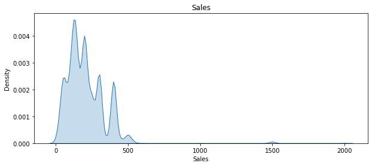

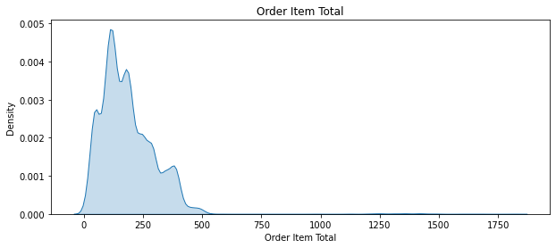

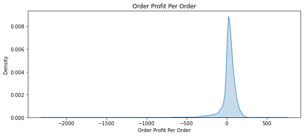

[1 more figures not shown]

```python
for column in data_num:
    plt.figure(figsize=(10,4))
    sns.kdeplot(data_num[column], fill=True)
    plt.title(column)
    plt.show()
```

```python
# Measure the skewness of each column
skewness = data_num.apply(lambda x: x.skew())
print(skewness)

# Normalize skewed data
#for column in data_num:
#    if np.min(data_num[column]) > 0: # Box-Cox Transformation requires strictly positive data
#        if data_num[column].skew() > 0.5 or data_num[column].skew() < -0.5: # check for skewness
#            data_num[column], _ = stats.boxcox(data_num[column]) # apply Box-Cox transformation
```

```
Days for shipping (real)         0.086850
Days for shipment (scheduled)   -0.717514
Benefit per order               -3.978533
Sales per customer               3.139386
Order Item Discount              3.451388
Order Item Discount Rate         0.349407
Order Item Product Price         3.549491
Order Item Profit Ratio         -2.867483
Order Item Quantity              0.886592
Sales                            3.276199
Order Item Total                 3.139386
Order Profit Per Order          -3.978533
Product Price                    3.549491
dtype: float64
```

```python
#data_num.apply(lambda x: x.skew())
```

```python
# Separate features and target
X = data_num.drop(["Days for shipping (real)","Days for shipment (scheduled)"], axis=1)
y = data_cat["Late_delivery_risk"].astype(int)

# Resampling configuration
#smote = SMOTE(random_state=rand_seed)

# Perform resampling
#X, y = smote.fit_resample(X, y)
```

```python
# Assuming X is your feature matrix and y are your labels
# Generate a random sample for training, testing, and validating
X_train, X_temp, y_train, y_temp = train_test_split(X, y, test_size=0.3, random_state=rand_seed, stratify=y)
X_val, X_test, y_val, y_test = train_test_split(X_temp, y_temp, test_size=0.5, random_state=rand_seed, stratify=y_temp)
```

**Support vector machines (SVMs)** are a set of supervised learning methods used for classification, regression and outliers detection.

The advantages of support vector machines are:

- Effective in high dimensional spaces.
- Still effective in cases where number of dimensions is greater than the number of samples.
- Uses a subset of training points in the decision function (called support vectors), so it is also memory efficient.
- Versatile: different Kernel functions can be specified for the decision function. Common kernels are provided, but it is also possible to specify custom kernels.

The disadvantages of support vector machines include:

- If the number of features is much greater than the number of samples, avoid over-fitting in choosing Kernel functions and regularization term is crucial.
- SVMs do not directly provide probability estimates, these are calculated using an expensive five-fold cross-validation (see Scores and probabilities, below).

The support vector machines in scikit-learn support both dense (numpy.ndarray and convertible to that by numpy.asarray) and sparse (any scipy.sparse) sample vectors as input. However, to use an SVM to make predictions for sparse data, it must have been fit on such data. For optimal performance, use C-ordered numpy.ndarray (dense) or scipy.sparse.csr_matrix (sparse) with dtype=float64.

Source: https://scikit-learn.org/stable/modules/svm.html

```python
# Train a Support Vector Machine

# Define the parameter grid
#param_grid = {
#    'C': [0.1, 1, 10, 100, 1000],
#    'kernel': ['linear', 'rbf', 'poly', 'sigmoid'],
#    'degree': [2, 3, 4],  # only used when kernel is 'poly'
#    'gamma': [1, 0.1, 0.01, 0.001, 0.0001],  # not used when kernel is 'linear'
#    'coef0': [0.0, 0.1, 0.5]  # only used when kernel is 'poly' or 'sigmoid'
#}


# Create a base model
#svm_base = svm.SVC(random_state=rand_seed)

#### Instantiate the grid search model
#grid_search = GridSearchCV(estimator=svm_base, param_grid=param_grid,
#                           cv=2, n_jobs=-1, verbose=2)

# Fit the grid search to the data
#grid_search.fit(X_train, y_train)

# Get the best parameters
#best_params = grid_search.best_params_

#print("Best parameters: ", best_params)
```

This hyper parameter tunning is not performed because it took a very long time to finish, even with stratified sampling it to 10% of the original data

```python
def eval_metrics(actual, pred):
    accuracy = accuracy_score(actual, pred)
    f1 = f1_score(actual, pred)
    recall = recall_score(actual, pred)
    precision = precision_score(actual, pred)
    return accuracy, f1, recall, precision
```

```python
mlflow.set_tracking_uri("http://localhost:5000")
mlflow.set_experiment("Order_Delivery")
```

```
<Experiment: artifact_location='mlflow-artifacts:/102778540419101379', creation_time=1696053492284, experiment_id='102778540419101379', last_update_time=1696053492284, lifecycle_stage='active', name='Order_Delivery', tags={}>
```

```
Accuracy: 0.5472673559822747
F1 Score: 0.7065581617999043
Recall: 0.9939393939393939
Precision: 0.5480876346082436
Validation Accuracy: 0.5491137370753324
Validation F1 Score: 0.7067018976699496
Validation Recall: 0.9905723905723905
Validation Precision: 0.5492905153099328
Feature: Benefit per order, Score: -0.00025
Feature: Sales per customer, Score: -0.04538
Feature: Order Item Discount, Score: -0.08485
Feature: Order Item Discount Rate, Score: -0.88036
Feature: Order Item Product Price, Score: -0.00023
Feature: Order Item Profit Ratio, Score: 0.00271
Feature: Order Item Quantity, Score: 0.01784
Feature: Sales, Score: 0.08883
Feature: Order Item Total, Score: -0.04538
Feature: Order Profit Per Order, Score: -0.00025
Feature: Product Price, Score: -0.00023
```

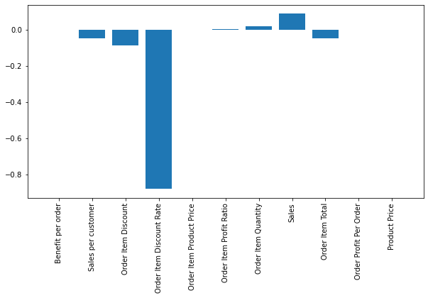

```
Registered model 'OrderDelivery' already exists. Creating a new version of this model...
2023/10/01 21:08:15 INFO mlflow.tracking._model_registry.client: Waiting up to 300 seconds for model version to finish creation. Model name: OrderDelivery, version 15
Created version '15' of model 'OrderDelivery'.
```

```python
if __name__ == "__main__":
    warnings.filterwarnings("ignore")
    rand_seed = 123
    np.random.seed(rand_seed)

    with mlflow.start_run(run_name="order_delivery_linear"):
        clf = svm.SVC(kernel="linear", random_state=rand_seed, probability= True)
        clf.fit(X_train, y_train)

        # Test SVM Model on Test Data
        y_pred = clf.predict(X_test)
        (accuracy, f1, recall, precision) = eval_metrics(y_test, y_pred)

        print(f"Accuracy: {accuracy}")
        print(f"F1 Score: {f1}")
        print(f"Recall: {recall}")
        print(f"Precision: {precision}")

        mlflow.log_param("accuracy", accuracy)
        mlflow.log_param("f1 score", f1)
        mlflow.log_param("recall", recall)
        mlflow.log_param("precision", precision)

        # Test SVM Model on validation data
        y_val_pred = clf.predict(X_val)
        (val_accuracy, val_f1, val_recall, val_precision) = eval_metrics(y_val, y_val_pred)

        print(f"Validation Accuracy: {val_accuracy}")
        print(f"Validation F1 Score: {val_f1}")
        print(f"Validation Recall: {val_recall}")
        print(f"Validation Precision: {val_precision}")

        mlflow.log_param("validation_accuracy", val_accuracy)
        mlflow.log_param("validation_f1 score", val_f1)
        mlflow.log_param("validation_recall", val_recall)
        mlflow.log_param("validation_precision", val_precision)

        # Assuming clf is your trained model
        try:
            # This will only work when clf is a linear model
            importance = clf.coef_[0]

            # summarize feature importance
            for i, j in enumerate(importance):
                print('Feature: %s, Score: %.5f' % (X_train.columns[i], j))

            # plot feature importance
            plt.figure(figsize=(10, 5))
            plt.bar(X_train.columns, importance)
            plt.xticks(rotation=90)  # Rotate feature names for readability
                    # Save the figure as a PNG
            if not os.path.exists("images"):
                os.mkdir("images")

            plt.savefig("feature_importance.png")
            mlflow.log_artifact("feature_importance.png")

            plt.show()
        except AttributeError:
            print("coef_ is only available when using a linear kernel")

        predictions = clf.predict(X_train)
        signature = infer_signature(X_train, predictions)
        tracking_url_type_store = urlparse(mlflow.get_tracking_uri()).scheme

        # Model registry does not work with file store
        if tracking_url_type_store != "file":
            mlflow.sklearn.log_model(clf, "model", registered_model_name="OrderDelivery", signature=signature)
        else:
            mlflow.sklearn.log_model(clf, "model", signature=signature)
```

[figure not shown]

```python
from IPython.display import Image
Image("D:\Kuliah\semester_3\kecerdasan_buatan\Github\Artificial_Inteligence\Pertemuan_4\mlflow_model_comparison.png")
```

Lets learn about how to interpret the metrics

1 - Accuracy is suitable with balanced dataset when there are an equal number of observations in each class which isn’t common in real-life problems.

2 - Precision is important when the cost of false positives is high.

3 - Recall is important when the cost of false negatives is high.

4 - F1 score considers both the precision and recall.

```python
# Create a LimeTabularExplainer
explainer = lime_tabular.LimeTabularExplainer(
    training_data=X_train.values,
    feature_names=X_train.columns,
    class_names=['0', '1'],
    mode='classification'
)

# Get the instance in the test set for which we want to explain the model's decision
instance = X_test.iloc[1]

# Generate explanations
exp = explainer.explain_instance(
    data_row=instance,
    predict_fn=clf.predict_proba,
    num_features=5,
    top_labels=1
)

# Visualize the explanation
exp.show_in_notebook(show_table=True, show_all=True)
```

[output not shown]

```python
import plotly.express as px
fig = px.scatter(data_1, x='Order Item Discount Rate', y='Sales', color='Late_delivery_risk')
fig.show()
```

[output not shown]

Based on the coefficient, Order Item Discount Rate have the highest influence (negatively) for the outcome. This might mean that the highest the discount rate is, the more likely the delivery will be on time.